# Preliminary results: Brain metastases in SEER-Medicare

Mustafa Ascha

December 11, 2017

# Purpose

This is a report describing my progress as I work towards completing my dissertation.  
I’ll aim to produce one of these each semester, along with the other material.

# Background

- SEER is among the largest cancer data collection programs in the world, and [covers about 28 percent of the US population](https://seer.cancer.gov/about/overview.html).
- In the past few years, SEER has released 2010 to 2013 data on brain metastases diagnosed at the time of primary cancer diagnosis (called “synchronous” brain metastases).
- While synchronous brain metastases are very informative, the lifetime frequencies of BM remain less well characterized.
- Consequently, the **first aim of this work is to:**
  1. Validate Medicare claims against SEER-reported BM and
  2. Describe the frequency of lifetime BM diagnoses in the Medicare population.
- Knowing which subjects were diagnosed with CNS metastases, and having detailed treatment records available in the form of Medicare inpatient, outpatient, and prescription claims, the **next aim is to:**
  1. Identify differences in BM frequency across primary cancer treatments and
  2. Describe BM treatment patterns across demographic and primary cancer characteristics.

# Methods

**Noteworthy issue:**

SEER does not have confidence in the use of claims data to identify secondary cancer diagnoses, though their references are mostly at least a decade old.  
Our work examining metastases has the benefit of:

1. Using diagnosis codes in conjunction with procedure codes and
2. Comparing these diagnostic criteria compare to recently-released SEER data on brain metastases

# Medicare claims caveats

**Diagnoses and dates of diagnoses**

- We will be examining the date of diagnosis closest to primary cancer diagnosis because SEER only provides data on “synchronous” brain metastases, which are those brain metastases diagnosed at the same time as the primary cancer
- These were searched for reference to a diagnosis code of 198.3X (CNS metastasis).
- The date of Medicare CNS mets diagnosis was compared to the date of primary cancer diagnosis to yield a number of days between primary and secondary CNS metastasis diagnosis, of which the minimum was taken to be the date of Medicare diagnosis.
- Procedure and treatment codes are currently being extracted

  **Available years**
- We have Medicare claims data for subjects diagnosed in 2008 through 2012
- SEER “synchronous” mets data is provided for the years 2010-2013
- Claims data was not available for the diagnosis year 2013 because we would need claims through 2015 to ensure sufficient coverage of patient care

# CNS Mets diagnosis - SEER vs Medicare

SEER definition/description of their “brain metastases” variable:

> Identifies the presence of distant metastatic involvement of the brain at the time of diagnosis.

> The presence of metastatic brain disease at diagnosis is an independent prognostic indicator, and it is used by Collaborative Staging to derive TNM-M codes and SEER Summary Stage codes for some sites.

> This field should be coded for all solid tumors, Kaposi sarcoma, Unknown Primary Site, and Other and Ill-Defined Primary Sites.

> **Only available for 2010+ diagnosis.**

> Note: This **includes only the brain, not spinal cord or other parts of the** **central nervous system**.

The following few definitions served to produce this report:

1. **Lifetime diagnoses** - Presence of an ICD9 code corresponding to secondary CNS cancer (198.3X)
2. **30-day diagnoses** - Presence of an ICD9 code corresponding to secondary CNS cancer (198.3X) *within 30 days of primary cancer diagnosis*
3. **90-day diagnoses** - Presence of an ICD9 code corresponding to secondary CNS cancer (198.3X) *within 90 days of primary cancer diagnosis*  
   The ICD diagnosis code only reaches a *central nervous system*-level description of metastases, but SEER specifically reports *brain* metastases. So, in addition to the CNS diagnosis code, we’ll also include intracranial procedure codes…

# Diagnosis identification next steps

To further refine diagnosis/procedure code criteria for the presence of brain metastases, the following diagnosis or procedure codes will be used in conjunction with secondary CNS cancer diagnosis codes:

- Head/neck diagnostic imaging procedure codes
- Intracranial biopsy
- Whole-brain radiation, stereotactic radiation therapies
- Neurosurgical resection
  - Not expecting many of these, given the age restrictions on our population  
    The following table shows the number of codes that will be examined, grouped by treatment or purpose for this work:

|  | CPT | HCPCS | ICD9 | ICD-9-CM |
| --- | --- | --- | --- | --- |
| **Biopsy** | 3 | 0 | 0 | 0 |
| **Diagnostic ICD** | 0 | 0 | 11 | 0 |
| **Diagnostic Imaging** | 26 | 0 | 0 | 0 |
| **Neurosurgical resection** | 85 | 0 | 0 | 8 |
| **Radiation Therapy** | 45 | 8 | 0 | 7 |
| **Stereotactic radiosurgery** | 9 | 7 | 0 | 5 |

# Study population

The following table summarises all records provided by SEER and IMS.

|  | breast | lung | skin |
| --- | --- | --- | --- |
| **n** | 111381 | 145210 | 44829 |
| **race** |  |  |  |
| **Asian** | 3819 ( 3.4) | 2604 ( 1.8) | 186 ( 0.4) |
| **Black** | 10447 ( 9.4) | 13120 ( 9.0) | 249 ( 0.6) |
| **Hispanic** | 1752 ( 1.6) | 866 ( 0.6) | 279 ( 0.6) |
| **Native American** | 291 ( 0.3) | 306 ( 0.2) | 41 ( 0.1) |
| **Other** | 3268 ( 2.9) | 2478 ( 1.7) | 216 ( 0.5) |
| **White** | 91804 ( 82.4) | 125836 ( 86.7) | 43858 ( 97.8) |
| **Sex: Male** | 1066 ( 1.0) | 76336 ( 52.6) | 29264 ( 65.3) |
| **Primary cancer diagnosis year:** |  |  |  |
| **1975 - 2007** | 8060 ( 7.2) | 16480 ( 11.3) | 8760 ( 19.5) |
| **2008** | 20076 ( 18.0) | 26770 ( 18.4) | 7011 ( 15.6) |
| **2009** | 20697 ( 18.6) | 26858 ( 18.5) | 7052 ( 15.7) |
| **2010** | 20344 ( 18.3) | 25458 ( 17.5) | 7279 ( 16.2) |
| **2011** | 20963 ( 18.8) | 25024 ( 17.2) | 7320 ( 16.3) |
| **2012** | 21240 ( 19.1) | 24620 ( 17.0) | 7407 ( 16.5) |

# Exclusion criteria

| Exclusion variable | value | breast | lung | skin |
| --- | --- | --- | --- | --- |
| n | Starting record count | 208909 | 211998 | 98299 |
| HMO Use | Used HMO | 3010 | 1856 | 2194 |
| Age | Under 65 years | 77764 | 47116 | 28264 |
| Diagnosis method | Autopsy/Death Certificate | 916 | 4878 | 139 |
| Medicare eligibility | ESRD only | 375 | 214 | 139 |
| Medicare eligibility | Aged with ESRD | 562 | 1120 | 236 |
| Medicare eligibility | Disabled | 25464 | 24078 | 5750 |
| Medicare eligibility | Disabled with ESRD | 215 | 180 | 37 |
| Race | Unknown | 1677 | 730 | 1130 |
| Survival Time (Months) | 9999 | 916 | 4878 | 139 |
| Death Verified | No | 145 | 1132 | 78 |
| Insurance Payer | Insurance status unknown | 8627 | 15560 | 24073 |
| Insurance Payer | Not insured | 1385 | 2928 | 586 |
| Heterogenous primaries | Unaccounted primaries present | 15062 | 1532 | 8189 |
| n | Total Left | 111381 | 145210 | 44829 |

# Exclusion diagram

[figure not shown]

# 30-day interval CNS Mets code

This table summarizes the number of subjects who were found to have a diagnosis code for secondary CNS cancer, where the code must have been used for billing at or within 30 days of primary cancer diagnosis.

[output not shown]

Which yields the following classification metrics:

| Site | Sensitivity | Specificity |
| --- | --- | --- |
| breast | 0.4655 | 0.9984 |
| lung | 0.6238 | 0.9836 |
| skin | 0.5365 | 0.999 |

# CNS Mets code within 90 days of primary cancer diagnosis

This table summarizes the number of subjects who were found to have a diagnosis code for secondary CNS cancer, where the code must have been used for billing at or within 90 days of primary cancer diagnosis.

| Site | CNS mets code w/in 90 days of primary | SEER Synchronous: Positive | SEER Synchronous: Negative |
| --- | --- | --- | --- |
| skin | Code Present | 131 | 49 |
| skin | Not Present | 61 | 21038 |
| lung | Code Present | 4834 | 1722 |
| lung | Not Present | 1610 | 61418 |
| breast | Code Present | 107 | 167 |
| breast | Not Present | 67 | 60819 |

Which yields the following classification metrics:

| Site | Sensitivity | Specificity |
| --- | --- | --- |
| breast | 0.6149 | 0.9973 |
| lung | 0.7502 | 0.9727 |
| skin | 0.6823 | 0.9977 |

# Lifetime code presence counts

This table summarizes the number of subjects who were found to have a diagnosis code for secondary CNS cancer, where the code must have been used for billing at any time with respect to date of primary cancer diagnosis.

| Site | Lifetime CNS code presence | SEER Synchronous: Positive | SEER Synchronous: Negative |
| --- | --- | --- | --- |
| skin | Code Present | 184 | 672 |
| skin | Not Present | 31 | 20513 |
| lung | Code Present | 6288 | 7292 |
| lung | Not Present | 874 | 56778 |
| breast | Code Present | 152 | 1249 |
| breast | Not Present | 45 | 59897 |

Which yields the following classification metrics:

| Site | Sensitivity | Specificity |
| --- | --- | --- |
| breast | 0.7716 | 0.9796 |
| lung | 0.878 | 0.8862 |
| skin | 0.8558 | 0.9683 |

# CNS code count visualization

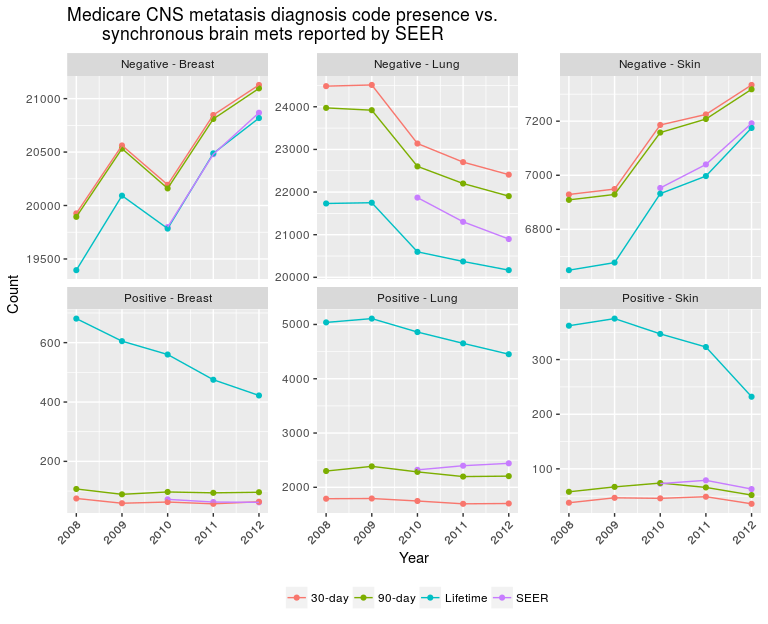

# Dissertation next steps

- Complete implementation of *brain* as opposed to *CNS* metastases
- Investigate missingness
- Stratify counts by primary cancer characteristics
- Clean up code for presentation
- Investigate primary treatment with respect to differences in brain metastases rates
- Investigate secondary treatment with respect to differences in treatment patterns for different demographics

# Consultation

If possible, I would love your opinions on the following. Just to be clear, I will address these questions later on because it’s somewhat of a priority to complete the paper on brain metastases frequencies before starting on these ideas.

- The Medicare claims codes pulled for this project included diagnostic procedures such as imaging or biopsy
  - Combine with above, goal of achieving greatest predictive value.
  - Dr. Sloan and Dr. Bordeaux, I really appreciate your perspectives on identifying brain metastases subjects using claims data. I realize there are a number of issues with claims data, but I would still love to hear your opinions on the process and its accuracy.
- Chemotherapy for brain metastases: Bevacizumab (Avastin) suggested due to BBB permeability?
  - Maybe look at vascular endothelial growth factor (VEGF) inhibitors generally?
  - Lou et al (2016) went so far as to ask, in their recent work: *Integrating bevacizumab and radiation treatment of brain metastasis: is there sense and sensibility in this approach?*
  - Treatment disparities for recently-released medication (it was FDA approved in 2004)?
  - Dr. Schumacher, do you think this might be an interesting line of inquiry?
- Conflicting evidence re: Efficacy of endocrine therapy with respect to brain metastases?
  - HER2 positive brain metastases respond to tamoxifen, megestrol acetate and aromatase inhibitors
  - Just as a thought, I’m interested in examining the relationship between hormonal chemotherapy and brain metastases development
- Dr. Sloan and Dr. Bordeaux: Does the presence of metastases in the spinal cord imply the presence of metastases in the brain?

# Consultation (continued)

- Examine responses to medications with respect to available genetic data (most relevant for breast cancer, given data)?
  - Emmanuelle Charafe-Jauffret, Christophe Ginestier, …, and Max S. Wicha. *Breast Cancer Cell Lines Contain Functional Cancer Stem Cells with Metastatic Capacity and a Distinct Molecular Signature*. Cancer Res February 15 2009 (69) (4) 1302-1313; DOI: 10.1158/0008-5472.CAN-08-2741
- Validate current clinical model treatment selection?
  - Lehmann BD, Bauer JA, Chen X, et al. *Identification of human triple-negative breast cancer subtypes and preclinical models for selection of targeted therapies*. The Journal of Clinical Investigation. 2011;121(7):2750-2767. doi:10.1172/JCI45014.
- Examine adherence to established standards for treatment?
  - Gaspar, L. E., Scott, C., Murray, K., & Curran, W. (2000). *Validation of the RTOG recursive partitioning analysis (RPA) classification for brain metastases*. International Journal of Radiation Oncology* Biology* Physics, 47(4), 1001-1006.
  - Videtic, G. M., Reddy, C. A., Chao, S. T., Rice, T. W., Adelstein, D. J., Barnett, G. H., … & Suh, J. H. (2009). *Gender, Race, and Survival: A Study in Non–Small-Cell Lung Cancer Brain Metastases Patients Utilizing the Radiation Therapy Oncology Group Recursive Partitioning Analysis Classification*. International Journal of Radiation Oncology* Biology* Physics, 75(4), 1141-1147.
- Examine primary cancer treatment in people who have advanced synchronous disease?
  - Essner, R., Lee, J. H., Wanek, L. A., Itakura, H., & Morton, D. L. (2004). *Contemporary surgical treatment of advanced-stage melanoma*. Archives of surgery, 139(9), 961-967.

# References

Leone, B.A. and Leone, J.P., 2015. Breast cancer brain metastases: the last frontier. Experimental hematology & oncology, 4(1), p.33.  
Lou, E. and Sperduto, P.W., 2016. Integrating bevacizumab and radiation treatment of brain metastasis: is there sense and sensibility in this approach?. Annals of translational medicine, 4(2).  
Niwińska A, Murawska M, Pogoda K. Breast cancer brain metastases: differences in survival depending on biological subtype, RPA RTOG prognostic class and systemic treatment after whole-brain radiotherapy (WBRT). Ann Oncol. 2010 May; 21(5):942-8.

# Appendix I: Criteria notes

1. **n :** This is the total number of records available from Medicare
2. **HMO Use : Used HMO** HMO use would imply a lack of reporting to Medicare, which would also mean it is inappropriate to include that subject in this work
3. **Age : Under 65 years** We need people who use Medicare due only to age, this helps keep the population homogenous
4. **Diagnosis method : Autopsy/Death Certificate** Primary cancer diagnosis on autopsy or death certificate would mean that a person wasn’t followed up by Medicare for their disease, or their disease was not clinically evident
5. **Medicare eligibility : ESRD only** We exclude people who are eligible due to ESRD only because their primary cancer disease process is unlike that of a subject without ESRD.
6. **Medicare eligibility : Aged with ESRD** This is the same as number 5, substituting the relevant eligibility value
7. **Medicare eligibility : Disabled** This is the same as number 5, substituting the relevant eligibility value
8. **Medicare eligibility : Disabled with ESRD** This is the same as number 5, substituting the relevant eligibility value
9. **Race : Unknown** I’ve seen this in other papers, but I would guess it’s because subjects whose race is not known are not followed up as well
10. **Survival Time (Months) : 9999** This value indicates a missing survival time, which doesn’t signal such great follow up
11. **Death Verified : No** Again, this is a signal of not-ideal follow-up
12. **Insurance Payer : Insurance status unknown** We’re only looking at people who used Medicare
13. **Insurance Payer : Not insured** We’re only looking at people who used Medicare
14. **Heterogenous primaries : Unaccounted primaries present** Each patient in SEER has a “sequence number” indicating which of the patient’s primary diagnoses that record represents. If a patient had a greater sequence number than they did records of breast/lung/skin cancer, then they were excluded from this analysis.